# chromosomix against reference implementations: time

Every command of the validation run again, as a fresh process, and timed against the package it reproduces

**Rendered** 6 November 2026, 00:06 UTC · **chromosomix** 0.21.0, release v0.21.0, at [`f2ac3bb`](https://github.com/js2264/chromosomix/commit/f2ac3bb1f5b34ee369e543f413398b80a79f3235)  
**By** GitHub Actions, [Notebooks run 22](https://github.com/js2264/chromosomix/actions/runs/42122173452), for its release  
**On** AMD EPYC 7763 64-Core Processor, 4 cores, 15.6 GB, Linux 7.0.0-1017-azure (x86_64); Python 3.13.18, Quarto 1.10.19

The commands are [the validation](https://chromosomix.app/validation/)’s, as it ran them. Beside this page: `timings.tsv`, every timed command, one row each. A map and a track from a file to a picture, beside juicebox.js and HiGlass: [the viewers](https://chromosomix.app/viewers/). Six analyses one after the other over a deep human map, against the same packages: [the laptop](https://chromosomix.app/laptop/).

[`validation.qmd`](https://chromosomix.app/validation/) runs each analysis twice, through `chromosomix` and through the package it reproduces, and writes every command it ran to `notebooks/work/validation/commands.json`. This notebook runs each of them again, exactly as written there but writing to a scratch folder, as a fresh process, `RUNS` times round robin (four, unless `TIMING_RUNS` in the environment says otherwise), the two sides of each pair taking turns to go first, and measures what each run costs: its **CPU time**, user and system, of the process and of every process it started and waited for; its **wall-clock time**; and its **peak memory**, the most those processes held together: their proportional set sizes — a page two of them share counted half in each, so that a pool of forked workers is not counted again in every worker — added up four times a second while the command runs, and never less than the largest resident set any one of them reached, which a sample can miss. A reference that runs four processes holds what the four hold. Where the system does not list a process’s children, as macOS does not, the peak memory is that largest resident set alone. How long a map and a track take to draw, beside the two viewers most used for the same thing, is a page of its own: [`viewers.qmd`](https://chromosomix.app/viewers/).

Every run of a command is one line of **`notebooks/work/validation/timings.tsv`**, a tidy table — one row per command and run, one column per variable, the machine and the versions included; every table and figure below is drawn from it.

**To render.** Render `validation.qmd` first, on the same machine: it fetches the data, makes every input and writes the command list, and this page runs those commands on those inputs. Then, in the same environment — the reference packages, yapc’s and pairtools’ own, and `chromosomix` built (`npm run build:cli`) — and on a machine left otherwise idle:

```bash
QUARTO_PYTHON=refs/bin/python quarto render notebooks/timing.qmd
```

A second render reads the table rather than timing again (`REDO`), unless the command list, the number of runs or the `chromosomix` build has changed. `.github/workflows/notebooks.yml` renders it on every release, on the runner that has just rendered the validation, and publishes this page at https://chromosomix.app/timings/ with its table beside it; the block under the title says which render, and which machine, this is.

```python
from pathlib import Path
import os

#: Timed runs of each command (TIMING_RUNS overrides it for a quick look), and whether to time them again.
#: Even, so that each side of a pair goes first in as many rounds as the other (`round_of`).
RUNS = int(os.environ.get('TIMING_RUNS', 4))
REDO = False

HERE = Path.cwd().resolve()
REPO = HERE.parent if HERE.name == 'notebooks' else HERE
WORK = REPO / 'notebooks' / 'work' / 'validation'
MANIFEST = WORK / 'commands.json'
TIMINGS = WORK / 'timings.tsv'
SCRATCH = WORK / 'timing'
```

```python
import json
import platform
import shlex
import shutil
import subprocess
import sys
import tempfile
import threading
import time
from collections import Counter
from itertools import groupby

import matplotlib.pyplot as plt
import numpy as np
import pandas as pd
from matplotlib.ticker import FuncFormatter, NullLocator

APP_COLOUR, REF = '#2a78d6', '#eb6834'
INK, INK2, GRID, SURFACE, MISSING = '#0b0b0b', '#52514e', '#e7e6e2', '#fcfcfb', '#efeeea'
plt.rcParams.update({
    'figure.facecolor': SURFACE, 'axes.facecolor': SURFACE, 'savefig.facecolor': SURFACE,
    'axes.edgecolor': INK2, 'axes.labelcolor': INK, 'xtick.color': INK2, 'ytick.color': INK2,
    'text.color': INK, 'axes.spines.top': False, 'axes.spines.right': False,
    'axes.grid': True, 'grid.color': GRID, 'grid.linewidth': 0.6, 'axes.axisbelow': True,
    'lines.linewidth': 2, 'font.size': 9, 'axes.titlesize': 10, 'axes.titleweight': 'bold',
    'axes.titlelocation': 'left', 'legend.frameon': False, 'figure.dpi': 110,
})


def show(frame, precision=2, **formats):
    """A table without row numbers: the columns named in `formats` their way, the others to `precision`."""
    return frame.style.hide(axis='index').format(formats or None, precision=precision)


def measures(values):
    """Named numbers as a two-column table."""
    return pd.DataFrame(list(values.items()), columns=['measure', 'value']).style.hide(axis='index')


def machine():
    """What the times were measured on, as columns of the table."""
    cpu = platform.processor()
    if Path('/proc/cpuinfo').exists():
        cpu = next((line.split(':', 1)[1].strip() for line in open('/proc/cpuinfo') if line.startswith('model name')), cpu)
    try:
        memory = round(os.sysconf('SC_PAGE_SIZE') * os.sysconf('SC_PHYS_PAGES') / 1e9, 1)
    except (ValueError, OSError):
        memory = np.nan
    node = subprocess.run(['node', '--version'], capture_output=True, text=True).stdout.strip()
    return {'processor': cpu, 'cores': os.cpu_count(), 'memory_gb': memory, 'system': platform.platform(),
            'node': node, 'python': platform.python_version()}


MACHINE = machine()
#: Whether the system lists a process's children and its proportional set size, as Linux does: where it does
#: not, as macOS does not, a run's peak memory is that of its largest process alone.
WEIGHS = (Path(f'/proc/self/task/{threading.get_native_id()}/children').exists()
          and Path('/proc/self/smaps_rollup').exists())
#: How often, in seconds, a run's processes are weighed while it runs.
EVERY = 0.25
```

## The machine

```python
if not MANIFEST.exists():
    raise FileNotFoundError(f'{MANIFEST} is not there: render validation.qmd first.')
LISTED = json.loads(MANIFEST.read_text())
OUT = LISTED['placeholder']
JOBS = [job for job in LISTED['commands'] if job['bench']]
measures({**MACHINE, 'commands timed': f"{len(JOBS)} of the {len(LISTED['commands'])} listed",
          'runs of each': RUNS, 'chromosomix': LISTED['chromosomix'],
          'processes a reference was given, where it takes them': LISTED['threads'],
          'peak memory': (f'every process of a run together, weighed every {EVERY} s' if WEIGHS
                          else 'the largest process of a run alone')})
```

| measure | value |
| --- | --- |
| processor | AMD EPYC 7763 64-Core Processor |
| cores | 4 |
| memory_gb | 16.800000 |
| system | Linux-7.0.0-1017-azure-x86_64-with-glibc2.39 |
| node | v24.22.2 |
| python | 3.13.18 |
| commands timed | 96 of the 166 listed |
| runs of each | 4 |
| chromosomix | 0.21.0 at f2ac3bb |
| processes a reference was given, where it takes them | 4 |
| peak memory | every process of a run together, weighed every 0.25 s |

## The runs

Each command is run as `validation.qmd` printed it, from `notebooks/work/validation/`, with its output sent to a scratch folder that is emptied after the run: all of them once, then all of them again, so a slow minute of the machine falls on every command rather than on one. `chromosomix` computes on one thread; a reference that takes a number of processes was given the number in the `threads` column.

**The two sides of a pair take turns to go first.** The list has each analysis’s `chromosomix` commands before its references, and the odd rounds run it so; the even rounds run each analysis’s references first, each side’s commands still in their own order. Whichever side runs first reads from the disk whatever of their shared input the page cache has let go since the round before, and the side after it finds it in memory. Run in one order, that wait fell on `chromosomix` every time: a metaplot whose bigWig had gone from the cache spent twelve seconds of its wall clock waiting on it, and `computeMatrix`, straight after, none. In turns, it falls on each side in half the rounds, which is why the number of rounds is even.

```python
def argv_for(job, scratch):
    """The command as it ran, writing to `scratch`."""
    if job['tool'] == 'chromosomix':
        return job['argv'] + ['--out', os.path.relpath(scratch, WORK)]
    target = os.path.relpath(scratch / job['out'], WORK)
    return [a.replace(OUT, target) for a in job['argv']]


def under(pid):
    """`pid` and every process under it, by the children each of their threads started."""
    found, todo = [], [pid]
    while todo:
        pid = todo.pop()
        found.append(pid)
        try:
            for tid in os.listdir(f'/proc/{pid}/task'):
                with open(f'/proc/{pid}/task/{tid}/children') as handle:
                    todo += [int(child) for child in handle.read().split()]
        except OSError:
            pass
    return found


def pss_kb(pid):
    """A process's proportional set size, in kB: its resident pages, one it shares with others counted as its
    share of it, so that a pool of forked workers is not counted again in each."""
    try:
        with open(f'/proc/{pid}/smaps_rollup') as handle:
            return next(int(line.split()[1]) for line in handle if line.startswith('Pss:'))
    except (OSError, StopIteration):
        return 0


def weigh(pid, done, peak, samples=None):
    """Every EVERY seconds until `done`, the processes under `pid` weighed together, the most into `peak[0]`,
    and each weighing into `samples`, with when it was taken, where there is a list to keep them."""
    while True:
        held = sum(pss_kb(p) for p in under(pid))
        peak[0] = max(peak[0], held)
        if samples is not None:
            samples.append((time.time(), held))
        if done.wait(EVERY):
            return


def timed(argv, extra, cwd=WORK, samples=None):
    """One run, from `cwd` (work/validation/): CPU seconds of the process and every process it started and
    waited for, wall seconds, and the most memory they held together, in MB; every weighing of them into
    `samples`, if it is a list."""
    env = None if extra is None else dict(os.environ, **extra)
    with tempfile.TemporaryFile() as err:
        start = time.perf_counter()
        process = subprocess.Popen(argv, cwd=cwd, env=env, stdout=subprocess.DEVNULL, stderr=err)
        done, peak = threading.Event(), [0]
        weigher = threading.Thread(target=weigh, args=(process.pid, done, peak, samples), daemon=True)
        if WEIGHS:
            weigher.start()
        _, status, usage = os.wait4(process.pid, 0)
        wall = time.perf_counter() - start
        done.set()
        if WEIGHS:
            weigher.join()
        process.returncode = os.waitstatus_to_exitcode(status)
        if process.returncode:
            err.seek(0)
            raise RuntimeError(f'{shlex.join(argv)}\n{err.read().decode(errors="replace")[-3000:]}')
    # ru_maxrss, the largest resident set any one of the processes reached, which a sample can miss: in
    # kilobytes on Linux and in bytes on macOS.
    largest = usage.ru_maxrss / (1024 * 1024 if sys.platform == 'darwin' else 1024)
    return {'cpu_s': usage.ru_utime + usage.ru_stime, 'user_s': usage.ru_utime, 'system_s': usage.ru_stime,
            'wall_s': wall, 'peak_mb': max(peak[0] / 1024, largest)}


#: The columns of the table, in order: what was run, the run, what it cost, where.
COLUMNS = ['section', 'analysis', 'data', 'command', 'tool', 'version', 'variant', 'group', 'threads', 'run',
           'order', 'cpu_s', 'user_s', 'system_s', 'wall_s', 'peak_mb', 'started', *MACHINE, 'chromosomix',
           'command_line']


def round_of(run):
    """The jobs round `run` runs, in its order, each with its place in the list (`order`): as listed on an
    odd round, each analysis's chromosomix commands before its references, and on an even one each
    analysis's references first, each side's commands in their own order."""
    listed = list(enumerate(JOBS))
    if run % 2 == 1:
        return listed
    turned = []
    for _, analysis in groupby(listed, key=lambda pair: (pair[1]['section'], pair[1]['analysis'])):
        analysis = list(analysis)
        turned += [pair for pair in analysis if pair[1]['tool'] != 'chromosomix']
        turned += [pair for pair in analysis if pair[1]['tool'] == 'chromosomix']
    return turned


def benchmark():
    rows = []
    for run in range(1, RUNS + 1):
        for order, job in round_of(run):
            scratch = SCRATCH / job['name']
            shutil.rmtree(scratch, ignore_errors=True)
            scratch.mkdir(parents=True)
            started = time.strftime('%Y-%m-%dT%H:%M:%S')
            cost = timed(argv_for(job, scratch), job['env'])
            shutil.rmtree(scratch, ignore_errors=True)
            rows.append({'section': job['section'], 'analysis': job['analysis'], 'data': job['data'],
                         'command': job['name'], 'tool': job['tool'], 'version': job['version'],
                         'variant': job['variant'], 'group': job['group'], 'threads': job['threads'], 'run': run,
                         'order': order, **cost, 'started': started, **MACHINE,
                         'chromosomix': LISTED['chromosomix'], 'command_line': job['command']})
        # Written after every round, so a long benchmark that is stopped keeps the rounds it finished.
        pd.DataFrame(rows, columns=COLUMNS).to_csv(TIMINGS, sep='\t', index=False)
    return pd.DataFrame(rows, columns=COLUMNS)


def current():
    """Whether the table on disk times every command listed, each RUNS times, with the chromosomix listed, in
    this notebook's columns."""
    if REDO or not TIMINGS.exists():
        return False
    held = pd.read_csv(TIMINGS, sep='\t', keep_default_na=False)
    if list(held.columns) != COLUMNS:
        return False
    runs = held.groupby('order')['run'].nunique()
    return (len(runs) == len(JOBS) and set(held['command']) == {job['name'] for job in JOBS}
            and (runs == RUNS).all() and set(held['chromosomix']) == {LISTED['chromosomix']})


if not current():
    SCRATCH.mkdir(parents=True, exist_ok=True)
    benchmark()
times = pd.read_csv(TIMINGS, sep='\t', keep_default_na=False)
measures({'runs in the table': f'{len(times):,}', 'columns': len(times.columns),
          'measured': f"{times['started'].min()} to {times['started'].max()}", 'table': os.path.relpath(TIMINGS, REPO)})
```

| measure | value |
| --- | --- |
| runs in the table | 384 |
| columns | 25 |
| measured | 2026-11-06T00:06:41 to 2026-11-06T01:56:35 |
| table | notebooks/work/validation/timings.tsv |

The table’s first lines:

```python
show(times.head(4))
```

| section | analysis | data | command | tool | version | variant | group | threads | run | order | cpu_s | user_s | system_s | wall_s | peak_mb | started | processor | cores | memory_gb | system | node | python | chromosomix | command_line |
| --- | --- | --- | --- | --- | --- | --- | --- | --- | --- | --- | --- | --- | --- | --- | --- | --- | --- | --- | --- | --- | --- | --- | --- | --- |
| 1 | Diamond insulation | mouse Hi-C, 10 kb, window 100 kb | insulation | chromosomix | 0.21.0 at f2ac3bb |  |  | 1 | 1 | 0 | 8.47 | 7.76 | 0.71 | 6.79 | 289.66 | 2026-11-06T00:06:41 | AMD EPYC 7763 64-Core Processor | 4 | 16.80 | Linux-7.0.0-1017-azure-x86_64-with-glibc2.39 | v24.22.2 | 3.13.18 | 0.21.0 at f2ac3bb | chromosomix insulation data/4DNFIOZ1TRUS.mcool::/resolutions/10000 --window 10 --out insulation/app |
| 1 | Diamond insulation | mouse Hi-C, 10 kb, window 100 kb | cooltools-insulation | cooltools | 0.7.1 |  |  | 4 | 1 | 1 | 18.54 | 17.52 | 1.02 | 8.33 | 962.73 | 2026-11-06T00:06:47 | AMD EPYC 7763 64-Core Processor | 4 | 16.80 | Linux-7.0.0-1017-azure-x86_64-with-glibc2.39 | v24.22.2 | 3.13.18 | 0.21.0 at f2ac3bb | python ../../scripts/cooltools_insulation.py data/4DNFIOZ1TRUS.mcool::/resolutions/10000 insulation/cooltools.tsv 4 |
| 2 | Directionality index | mouse Hi-C, 50 kb, window 2 Mb | di | chromosomix | 0.21.0 at f2ac3bb |  |  | 1 | 1 | 2 | 4.12 | 3.86 | 0.26 | 3.10 | 184.72 | 2026-11-06T00:06:56 | AMD EPYC 7763 64-Core Processor | 4 | 16.80 | Linux-7.0.0-1017-azure-x86_64-with-glibc2.39 | v24.22.2 | 3.13.18 | 0.21.0 at f2ac3bb | chromosomix di data/4DNFIOZ1TRUS.mcool::/resolutions/50000 --window 40 --out di/app |
| 2 | Directionality index | mouse Hi-C, 50 kb, window 2 Mb | domaincaller-di | domaincaller | 0.1.0 |  |  | 1 | 1 | 3 | 3.84 | 3.67 | 0.18 | 3.52 | 263.54 | 2026-11-06T00:06:59 | AMD EPYC 7763 64-Core Processor | 4 | 16.80 | Linux-7.0.0-1017-azure-x86_64-with-glibc2.39 | v24.22.2 | 3.13.18 | 0.21.0 at f2ac3bb | python ../../scripts/domaincaller_di.py data/4DNFIOZ1TRUS.mcool::/resolutions/50000 di/domaincaller.npy |

## Each command

CPU and wall-clock seconds, mean ± sd over the runs, and the peak memory of the largest run.

```python
KEY = ['section', 'analysis', 'tool', 'variant', 'group', 'command', 'order']
per = (times.groupby(KEY, sort=False)
       .agg(cpu=('cpu_s', 'mean'), cpu_sd=('cpu_s', 'std'), wall=('wall_s', 'mean'), wall_sd=('wall_s', 'std'),
            peak=('peak_mb', 'max'))
       .reset_index().sort_values('order').reset_index(drop=True))
per['CPU s'] = [f'{m:.2f} ± {s:.2f}' for m, s in zip(per['cpu'], per['cpu_sd'])]
per['wall s'] = [f'{m:.2f} ± {s:.2f}' for m, s in zip(per['wall'], per['wall_sd'])]
per['peak MB'] = per['peak'].round().astype(int)
show(per[['section', 'analysis', 'tool', 'variant', 'CPU s', 'wall s', 'peak MB']], **{'peak MB': '{:,}'})
```

| section | analysis | tool | variant | CPU s | wall s | peak MB |
| --- | --- | --- | --- | --- | --- | --- |
| 1 | Diamond insulation | chromosomix |  | 8.53 ± 0.11 | 6.82 ± 0.04 | 290 |
| 1 | Diamond insulation | cooltools |  | 18.68 ± 0.16 | 8.40 ± 0.07 | 963 |
| 2 | Directionality index | chromosomix |  | 4.14 ± 0.03 | 3.09 ± 0.02 | 206 |
| 2 | Directionality index | domaincaller |  | 3.91 ± 0.06 | 3.59 ± 0.06 | 264 |
| 3 | Compartments | chromosomix |  | 9.81 ± 0.02 | 7.26 ± 0.05 | 278 |
| 3 | Compartments | cooltools |  | 19.48 ± 0.22 | 11.40 ± 0.20 | 607 |
| 4 | P(s) | chromosomix | yeast 800 bp | 1.21 ± 0.02 | 0.87 ± 0.01 | 179 |
| 4 | P(s) | chromosomix | mouse 10 kb | 4.61 ± 0.03 | 3.76 ± 0.03 | 267 |
| 4 | P(s) | cooltools | yeast 800 bp | 4.36 ± 0.07 | 3.68 ± 0.07 | 992 |
| 4 | P(s) | cooltools | mouse 10 kb | 37.20 ± 5.42 | 21.83 ± 10.93 | 11,835 |
| 5 | Peak calling (yapc, IDR) | chromosomix |  | 33.09 ± 0.39 | 30.34 ± 0.31 | 288 |
| 5 | Peak calling (yapc, IDR) | yapc 0.1 | seed 0 | 100.86 ± 0.85 | 101.05 ± 0.92 | 1,667 |
| 6 | Loops (chromosight) | chromosomix |  | 9.97 ± 0.25 | 8.37 ± 0.22 | 281 |
| 6 | Loops (chromosight) | chromosight |  | 58.35 ± 0.53 | 19.73 ± 0.24 | 818 |
| 7 | Reproducibility (HiCRep) | chromosomix | 3 maps, 3 pairs | 6.47 ± 0.19 | 5.30 ± 0.14 | 266 |
| 7 | Reproducibility (HiCRep) | hicrep | 3 maps, 3 pairs | 8.10 ± 0.14 | 7.81 ± 0.11 | 263 |
| 8 | 3D model (pastis-NB) | chromosomix | seed 0 | 9.48 ± 0.05 | 9.01 ± 0.04 | 201 |
| 8 | 3D model (pastis-NB) | pastis | seed 0 | 118.34 ± 0.97 | 58.91 ± 0.42 | 370 |
| 9 | Coverage | chromosomix | raw | 6.30 ± 0.05 | 5.06 ± 0.03 | 271 |
| 9 | Coverage | chromosomix | balanced | 6.63 ± 0.08 | 5.47 ± 0.03 | 332 |
| 9 | Coverage | cooltools | raw | 8.28 ± 0.06 | 4.00 ± 0.06 | 1,637 |
| 9 | Coverage | cooltools | balanced | 9.05 ± 0.08 | 4.58 ± 0.06 | 1,818 |
| 10 | Virtual 4C | chromosomix | Sox2 | 2.04 ± 0.03 | 1.55 ± 0.01 | 261 |
| 10 | Virtual 4C | cooltools | Sox2 | 11.60 ± 0.07 | 4.81 ± 0.04 | 628 |
| 11 | Aggregate peak analysis | chromosomix | raw | 2.16 ± 0.02 | 1.55 ± 0.01 | 202 |
| 11 | Aggregate peak analysis | chromosomix | raw, every loop | 3.38 ± 0.05 | 2.47 ± 0.03 | 206 |
| 11 | Aggregate peak analysis | chromosomix | on the diagonal, raw | 3.64 ± 0.04 | 2.64 ± 0.02 | 213 |
| 11 | Aggregate peak analysis | chromosomix | controls, seed 1 | 3.93 ± 0.05 | 2.90 ± 0.02 | 201 |
| 11 | Aggregate peak analysis | coolpuppy | raw | 13.43 ± 0.12 | 5.34 ± 0.10 | 1,090 |
| 11 | Aggregate peak analysis | coolpuppy | raw, every loop | 14.19 ± 0.17 | 5.59 ± 0.09 | 1,034 |

[output cut: 66 more lines]

## Against the references

For each analysis, the `chromosomix` commands against the reference commands they are paired with — the same variant, or the analysis’s one reference — as a fold: the reference’s seconds over the app’s, summed where a side is several commands, which the table names. deepTools’ metaplot is `computeMatrix` and then `plotProfile` — and `plotHeatmap`, over two tracks — against one `chromosomix metaplot`; its track correlation is `multiBigwigSummary` and then `plotCorrelation` once a method, against `chromosomix trackcorr` once a method.

```python
#: Each timed command's line, by its name, for what the pairs below add up.
LINES = {job['name']: job['command'] for job in JOBS}


def program(name):
    """What a timed command runs: chromosomix's task, a reference script's name, or the program."""
    words = shlex.split(LINES[name])
    if words[0] == 'chromosomix':
        return words[1]
    if words[0].endswith('python'):
        return Path(words[1]).stem
    return words[0]


def summed(rows):
    """The commands one side of a pair adds up, in order, a repeated one counted: `plotCorrelation ×2`."""
    counts = Counter(program(name) for name in rows['command'])
    return ' + '.join(name if n == 1 else f'{name} ×{n}' for name, n in counts.items())


def pairs():
    out = []
    for (section, analysis), rows in per.groupby(['section', 'analysis'], sort=False):
        apps, refs = rows[rows['tool'] == 'chromosomix'], rows[rows['tool'] != 'chromosomix']
        for group, mine in apps.groupby('group', sort=False):
            theirs = refs[refs['group'] == group]
            if theirs.empty and refs['group'].nunique() == 1:
                theirs = refs
            if theirs.empty:
                continue
            out.append({'section': section, 'analysis': analysis, 'variant': group or '—',
                        'reference': ', '.join(dict.fromkeys(theirs['tool'])),
                        'chromosomix commands': summed(mine), 'reference commands': summed(theirs),
                        'chromosomix CPU s': mine['cpu'].sum(), 'reference CPU s': theirs['cpu'].sum(),
                        'chromosomix wall s': mine['wall'].sum(), 'reference wall s': theirs['wall'].sum(),
                        'chromosomix peak MB': mine['peak'].max(), 'reference peak MB': theirs['peak'].max()})
    frame = pd.DataFrame(out)
    frame['× faster, CPU'] = frame['reference CPU s'] / frame['chromosomix CPU s']
    frame['× faster, wall'] = frame['reference wall s'] / frame['chromosomix wall s']
    return frame


folds = pairs()
show(folds, **{'× faster, CPU': '{:.1f}×', '× faster, wall': '{:.1f}×', 'chromosomix peak MB': '{:,.0f}',
               'reference peak MB': '{:,.0f}'})
```

| section | analysis | variant | reference | chromosomix commands | reference commands | chromosomix CPU s | reference CPU s | chromosomix wall s | reference wall s | chromosomix peak MB | reference peak MB | × faster, CPU | × faster, wall |
| --- | --- | --- | --- | --- | --- | --- | --- | --- | --- | --- | --- | --- | --- |
| 1 | Diamond insulation | — | cooltools | insulation | cooltools_insulation | 8.53 | 18.68 | 6.82 | 8.40 | 290 | 963 | 2.2× | 1.2× |
| 2 | Directionality index | — | domaincaller | di | domaincaller_di | 4.14 | 3.91 | 3.09 | 3.59 | 206 | 264 | 0.9× | 1.2× |
| 3 | Compartments | — | cooltools | compartments | cooltools_eigs_cis | 9.81 | 19.48 | 7.26 | 11.40 | 278 | 607 | 2.0× | 1.6× |
| 4 | P(s) | yeast 800 bp | cooltools | expected | cooltools_expected_cis | 1.21 | 4.36 | 0.87 | 3.68 | 179 | 992 | 3.6× | 4.2× |
| 4 | P(s) | mouse 10 kb | cooltools | expected | cooltools_expected_cis | 4.61 | 37.20 | 3.76 | 21.83 | 267 | 11,835 | 8.1× | 5.8× |
| 5 | Peak calling (yapc, IDR) | — | yapc 0.1 | peaks | yapc_idr | 33.09 | 100.86 | 30.34 | 101.05 | 288 | 1,667 | 3.0× | 3.3× |
| 6 | Loops (chromosight) | — | chromosight | chromosight | chromosight | 9.97 | 58.35 | 8.37 | 19.73 | 281 | 818 | 5.9× | 2.4× |
| 7 | Reproducibility (HiCRep) | 3 maps, 3 pairs | hicrep | hicrep_scc | hicrep_scc | 6.47 | 8.10 | 5.30 | 7.81 | 266 | 263 | 1.3× | 1.5× |
| 8 | 3D model (pastis-NB) | seed 0 | pastis | reconstruct3d | pastis_nb | 9.48 | 118.34 | 9.01 | 58.91 | 201 | 370 | 12.5× | 6.5× |
| 9 | Coverage | raw | cooltools | coverage | cooltools_coverage | 6.30 | 8.28 | 5.06 | 4.00 | 271 | 1,637 | 1.3× | 0.8× |
| 9 | Coverage | balanced | cooltools | coverage | cooltools_coverage | 6.63 | 9.05 | 5.47 | 4.58 | 332 | 1,818 | 1.4× | 0.8× |
| 10 | Virtual 4C | Sox2 | cooltools | fourc | cooltools_virtual4c | 2.04 | 11.60 | 1.55 | 4.81 | 261 | 628 | 5.7× | 3.1× |
| 11 | Aggregate peak analysis | raw | coolpuppy | apa | coolpuppy_pileup | 2.16 | 13.43 | 1.55 | 5.34 | 202 | 1,090 | 6.2× | 3.4× |
| 11 | Aggregate peak analysis | raw, every loop | coolpuppy | apa | coolpuppy_pileup | 3.38 | 14.19 | 2.47 | 5.59 | 206 | 1,034 | 4.2× | 2.3× |
| 11 | Aggregate peak analysis | on the diagonal, raw | coolpuppy | apa | coolpuppy_pileup | 3.64 | 14.92 | 2.64 | 5.77 | 213 | 1,090 | 4.1× | 2.2× |
| 11 | Aggregate peak analysis | controls | coolpuppy | apa | coolpuppy_pileup | 3.93 | 14.42 | 2.90 | 5.55 | 201 | 1,027 | 3.7× | 1.9× |
| 12 | APA, chromosight's score | — | chromosight | apa | chromosight | 8.49 | 137.66 | 6.54 | 43.56 | 255 | 1,505 | 16.2× | 6.7× |
| 13 | Boost-HiC | chr1, 1,955 bins | Boost-HiC | boost | boosthic | 6.31 | 30.04 | 5.98 | 29.53 | 636 | 475 | 4.8× | 4.9× |
| 14 | Metaplot | TSS | deepTools | metaplot | computeMatrix + plotProfile | 6.77 | 7.72 | 5.63 | 7.53 | 382 | 229 | 1.1× | 1.3× |
| 14 | Metaplot | TSS, two tracks | deepTools | metaplot | computeMatrix + plotProfile + plotHeatmap | 11.95 | 16.93 | 9.88 | 13.00 | 439 | 494 | 1.4× | 1.3× |
| 15 | Interval overlap | — | bedtools | overlap | bedtools_overlap | 1.60 | 71.81 | 1.49 | 64.94 | 135 | 135 | 45.0× | 43.7× |
| 16 | Base composition | — | bioframe, Biopython | composition | composition | 6.14 | 56.38 | 6.80 | 56.18 | 302 | 512 | 9.2× | 8.3× |
| 17 | Motif search | TGACTCA, ≤ 1 mismatch | seqkit | motif | seqkit | 8.47 | 26.30 | 8.18 | 25.75 | 359 | 4,119 | 3.1× | 3.1× |
| 17 | Motif search | WGATAR | seqkit | motif | seqkit | 6.78 | 11.58 | 6.46 | 10.93 | 319 | 343 | 1.7× | 1.7× |
| 18 | Track correlation | 100 bp windows | deepTools | trackcorr ×2 | multiBigwigSummary + plotCorrelation ×2 | 3.60 | 371.54 | 2.97 | 100.25 | 318 | 311 | 103.2× | 33.8× |
| 18 | Track correlation | 1,000 bp windows | deepTools | trackcorr ×2 | multiBigwigSummary + plotCorrelation ×2 | 2.50 | 37.71 | 1.78 | 11.75 | 180 | 160 | 15.1× | 6.6× |
| 18 | Track correlation | 10,000 bp windows | deepTools | trackcorr ×2 | multiBigwigSummary + plotCorrelation ×2 | 2.32 | 7.89 | 1.63 | 3.76 | 169 | 153 | 3.4× | 2.3× |
| 19 | Loop calling | — | cooltools | loops | cooltools_dots | 43.01 | 949.54 | 37.76 | 264.95 | 465 | 11,473 | 22.1× | 7.0× |
| 23 | Signal by group | one value per entry | pyBigWig, SciPy | groupsignal | pybigwig_groupsignal | 1.03 | 1.93 | 0.73 | 1.31 | 196 | 150 | 1.9× | 1.8× |
| 24 | CTCF sites in GM12878 (Fig. 2) | insulation | cooltools | insulation | cooltools_insulation_scales | 2.06 | 8.26 | 1.53 | 7.62 | 196 | 870 | 4.0× | 5.0× |
| 24 | CTCF sites in GM12878 (Fig. 2) | peaks | yapc 0.1 | peaks | yapc_idr | 62.28 | 125.24 | 58.50 | 125.48 | 274 | 1,595 | 2.0× | 2.1× |
| 24 | CTCF sites in GM12878 (Fig. 2) | APA | coolpuppy | apa ×2 | coolpuppy_pileup ×2 | 2.83 | 9.17 | 2.03 | 8.12 | 229 | 1,199 | 3.2× | 4.0× |
| 24 | CTCF sites in GM12878 (Fig. 2) | metaplot, signal | deepTools | metaplot | computeMatrix + plotProfile + plotHeatmap | 1.82 | 4.73 | 1.40 | 3.45 | 265 | 145 | 2.6× | 2.5× |
| 24 | CTCF sites in GM12878 (Fig. 2) | metaplot, insulation | deepTools | metaplot | computeMatrix + plotProfile + plotHeatmap | 1.98 | 67.90 | 1.62 | 20.99 | 193 | 946 | 34.3× | 13.0× |
| 25 | Pairs statistics | — | pairtools | stats | pairtools | 136.99 | 118.23 | 117.99 | 103.08 | 293 | 311 | 0.9× | 0.9× |
| 26 | Restriction sites | — | bioframe, Biopython | restriction | bioframe_digest | 1.79 | 1.69 | 1.62 | 1.37 | 142 | 135 | 0.9× | 0.8× |
| 28 | TAD annotation | raw | Juicer Tools | arrowhead | java | 9.18 | 60.25 | 10.18 | 31.42 | 530 | 5,643 | 6.6× | 3.1× |
| 28 | TAD annotation | balanced | Juicer Tools | arrowhead | java | 9.31 | 65.92 | 10.16 | 32.99 | 613 | 4,579 | 7.1× | 3.2× |
| 29 | Map report | — | cooler | mapreport | map_resolution | 5.45 | 7.56 | 4.52 | 7.29 | 237 | 864 | 1.4× | 1.6× |

```python
fold = folds['× faster, CPU']
TEXT = {'fold': f'{np.exp(np.log(fold).mean()):.1f}', 'n': f'{len(fold)}',
        'range': f'{fold.min():.1f}× to {fold.max():.1f}×',
        'slower': ', '.join(f"{a} ({v})" for a, v, f in zip(folds['analysis'], folds['variant'], fold) if f < 1) or 'none',
        'sd': f"{(per['cpu_sd'] / per['cpu']).max():.0%}",
        'wall': f"{np.exp(np.log(folds['× faster, wall']).mean()):.1f}"}
```

Over the 39 pairs, `chromosomix` takes **4.1 times less CPU** than the reference tools, as a geometric mean of the folds above (0.9× to 103.2×), and 3.0 times less wall-clock time. Slower than its reference: Directionality index (—), Pairs statistics (—), Restriction sites (—). No command’s CPU time spreads by more than 15% of its mean across runs.

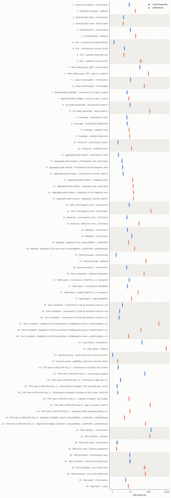

Figure 1: CPU time of every job, one row a side of a pair in the table above, its commands added up run by run (deepTools’ computeMatrix and plotProfile on one line); each run a dot and the mean a bar, on a logarithmic axis; the rows of one analysis share a band.

```python
def jobs():
    """One row a side of each pair: an analysis's chromosomix commands of one group, or its reference's, with
    every run's CPU seconds added up across them, as the pairs above add them."""
    side = np.where(per['tool'] == 'chromosomix', 'chromosomix', 'reference')
    out = []
    for (section, analysis, _, group), rows in per.groupby(['section', 'analysis', side, 'group'], sort=False):
        # By their places in the list: an analysis may give its chromosomix command and its reference one name.
        runs_ = times[times['order'].isin(rows['order'])].groupby('run')['cpu_s'].sum()
        groups = per.loc[(per['section'] == section) & (per['analysis'] == analysis), 'group'].nunique()
        if len(rows) == 1:
            what = rows['variant'].iloc[0]
        else:
            what = (f'{group}: ' if groups > 1 and group else '') + summed(rows)
        out.append({'section': section, 'analysis': analysis, 'tool': ', '.join(dict.fromkeys(rows['tool'])),
                    'what': what, 'runs': runs_.to_numpy(), 'cpu': runs_.mean()})
    return out


JOB_ROWS = jobs()
fig, ax = plt.subplots(figsize=(10, 0.36 * len(JOB_ROWS) + 1.2), layout='constrained')
y = np.arange(len(JOB_ROWS))[::-1]
BANDS = [row['analysis'] for row in JOB_ROWS]
for k, analysis in enumerate(dict.fromkeys(BANDS)):
    if k % 2:
        at = y[[i for i, one in enumerate(BANDS) if one == analysis]]
        ax.axhspan(at.min() - 0.5, at.max() + 0.5, color=MISSING, lw=0, zorder=0)
for yi, row in zip(y, JOB_ROWS):
    colour = APP_COLOUR if row['tool'] == 'chromosomix' else REF
    ax.scatter(row['runs'], np.full(len(row['runs']), yi), s=14, color=colour, alpha=0.55, lw=0, zorder=3)
    ax.plot([row['cpu']] * 2, [yi - 0.3, yi + 0.3], color=colour, lw=2.5, zorder=4)
labels = [f"{row['section']} · {row['analysis']} · {row['tool']}" + (f" ({row['what']})" if row['what'] else '')
          for row in JOB_ROWS]
ax.set_yticks(y, labels, fontsize=8)
ax.set_xscale('log')
ALL_RUNS = np.concatenate([row['runs'] for row in JOB_ROWS])
ax.set_xlim(ALL_RUNS.min() / 1.5, ALL_RUNS.max() * 1.5)
ax.xaxis.set_major_formatter(FuncFormatter(lambda v, _: f'{v:g}'))
ax.xaxis.set_minor_locator(NullLocator())
ax.set(xlabel='CPU time (s)', ylim=(-0.5, len(JOB_ROWS) - 0.5))
ax.grid(axis='y', visible=False)
ax.scatter([], [], s=24, color=APP_COLOUR, label='chromosomix')
ax.scatter([], [], s=24, color=REF, label='reference')
ax.legend(loc='upper right')
plt.show()
```

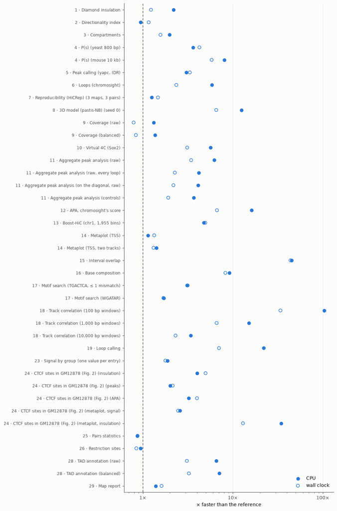

Figure 2: How many times less CPU (filled) and wall-clock time (open) chromosomix takes than its reference, pair by pair; right of the line is faster.

```python
fig, ax = plt.subplots(figsize=(9, 0.32 * len(folds) + 1.2), layout='constrained')
y = np.arange(len(folds))[::-1]
ax.scatter(folds['× faster, CPU'], y, s=36, color=APP_COLOUR, label='CPU', zorder=3)
ax.scatter(folds['× faster, wall'], y, s=36, facecolors='none', edgecolors=APP_COLOUR, label='wall clock', zorder=3)
ax.axvline(1, color=INK2, lw=1, ls=(0, (4, 3)))
ax.set_yticks(y, [f"{s} · {a}" + (f' ({v})' if v != '—' else '') for s, a, v in
                  zip(folds['section'], folds['analysis'], folds['variant'])], fontsize=8)
ax.set_xscale('log')
ax.xaxis.set_major_formatter(FuncFormatter(lambda v, _: f'{v:g}×'))
ax.set(xlabel='× faster than the reference', ylim=(-0.5, len(folds) - 0.5))
ax.grid(axis='y', visible=False)
ax.legend(loc='lower right')
plt.show()
```

*Rendered in 110 min 3 s, from 6 November 2026, 00:06 UTC to 01:56 UTC, by chromosomix 0.21.0 at `f2ac3bb`.*